# VERIANALIZI

2023-06-01

####1.ADIM

Veri Tanımı 2021’de bir çevrimiçi mağaza tarafından toplanan satış verileridir. Bu veri 11 sütun 65787 gözlemden oluşmaktadır. Verideki gözlem sayısı fazla olduğundan verinin yaklaşık %3’ü örneklem olarak yani 1965 gözlem seçilmiştir.

Proje Tanımı Çevrimiçi mağazadaki satışların kupon kullanımına bağlı olarak web sitesinde geçirilen sürede müşterinin toplam satış oranının incelenmesi

Değişken tanımları;

| Değişken adı | Türkçesi |
| --- | --- |
| Age | Müşterinin yaşı |
| Gender | Cinsiyet |
| Revenue_Total | Müşteriye göre toplam satışlar |
| N_Purchases | En son satın alma sayısı |
| Purchase_DATE | En son satın alma tarihi |
| Purchase_VALUE | € cinsinden son satın alma |
| Pay_Method | Ödeme Türü |
| Time_Spent | Web sitesinde geçirilen süre(saniye) |
| Browser | Tarayıcı |
| Newsletter | Abonelik |
| Voucher | Kupon kullanımı |

```r
library(readxl)
satisveri <- read_excel("C:/Users/Acer/Desktop/odev.xlsx")
View(satisveri)
```

Kategorik verilerin açılımı;

| Kategorik Veri | Açıklama |
| --- | --- |
| Gender | **0**: Erkek, **1**:Kadın |
| Pay_Method | **0**: Dijital Cüzdanlar, **1**: Kart, **2**: PayPal, **3**: Diğer |
| Browser | **0**: Chrome, **1**: Safari, **2**: Edge, **3**: Diğer |
| Newsletter | **0**: Abone olmadım, **1**: Abone oldum |
| Voucher | **0**: kullanılmadı, **1**: kullanıldı |

####2.ADIM

###Proje Tanımı

Çevrimiçi mağazadaki satışların kupon kullanımına bağlı olarak web sitesinde geçirilen sürede müşterinin toplam satış oranının incelenmesi

####3.ADIM

###Verilerin Toplanması

Age, Revenue_total, N_Purchases, Purchase_VALUE, Time_Spent Nicel; Pay_Method, Browser, Newsletter, Voucher Nitel verilerdir.

####4.ADIM

###Verinin Yapısı ve Niteliği

```r
satisveri <- as.data.frame(satisveri)
satisveri$Gender <- as.factor(satisveri$Gender)
satisveri$Pay_Method <- as.factor(satisveri$Pay_Method)
satisveri$Browser <- as.factor(satisveri$Browser)
satisveri$Newsletter <- as.factor(satisveri$Newsletter)
satisveri$Voucher <- as.factor(satisveri$Voucher)

summary(satisveri)
```

```
##       Age        Gender   Revenue_Total    N_Purchases
##  Min.   :16.00   0: 647   Min.   : 0.50   Min.   :1.000
##  1st Qu.:27.00   1:1318   1st Qu.:15.80   1st Qu.:2.000
##  Median :39.00            Median :30.10   Median :4.000
##  Mean   :39.28            Mean   :27.77   Mean   :4.005
##  3rd Qu.:51.00            3rd Qu.:37.60   3rd Qu.:6.000
##  Max.   :63.00            Max.   :59.90   Max.   :7.000
##  Purchase_DATE                 Purchase_VALUE     Pay_Method   Time_Spent
##  Min.   :2021-01-01 00:00:00   Length:1965        0:555      Min.   : 120.0
##  1st Qu.:2021-04-03 00:00:00   Class :character   1:576      1st Qu.: 354.0
##  Median :2021-06-30 00:00:00   Mode  :character   2:439      Median : 587.0
##  Mean   :2021-07-02 01:38:55                      3:395      Mean   : 593.7
##  3rd Qu.:2021-09-29 00:00:00                                 3rd Qu.: 833.0
##  Max.   :2022-01-01 00:00:00                                 Max.   :1080.0
##  Browser  Newsletter Voucher
##  0:1265   0:1675     0:1437
##  1: 399   1: 290     1: 528
##  2:  96
##  3: 205
##
##
```

```r
str(satisveri)
```

```
## 'data.frame':    1965 obs. of  11 variables:
##  $ Age           : num  42 63 59 42 30 21 21 45 49 57 ...
##  $ Gender        : Factor w/ 2 levels "0","1": 1 1 2 2 1 2 2 2 1 2 ...
##  $ Revenue_Total : num  2.1 5.6 14.3 38.3 34.5 45.3 39.7 30.3 53.5 4 ...
##  $ N_Purchases   : num  1 1 1 3 7 6 6 1 2 6 ...
##  $ Purchase_DATE : POSIXct, format: "2021-10-29" "2021-02-26" ...
##  $ Purchase_VALUE: chr  "2,1" "5,6" "14,3" "9.575" ...
##  $ Pay_Method    : Factor w/ 4 levels "0","1","2","3": 3 4 1 1 3 2 1 1 2 1 ...
##  $ Time_Spent    : num  991 964 139 1008 752 ...
##  $ Browser       : Factor w/ 4 levels "0","1","2","3": 1 1 1 1 1 2 4 1 2 1 ...
##  $ Newsletter    : Factor w/ 2 levels "0","1": 1 1 1 2 1 1 1 1 1 1 ...
##  $ Voucher       : Factor w/ 2 levels "0","1": 1 2 2 1 2 1 2 1 1 2 ...
```

```r
rowSums(is.na(satisveri))
```

[output not shown]

[output cut: 39 more lines]

```r
colSums(is.na(satisveri))
```

```
##            Age         Gender  Revenue_Total    N_Purchases  Purchase_DATE
##              0              0              0              0              0
## Purchase_VALUE     Pay_Method     Time_Spent        Browser     Newsletter
##              0              0              0              0              0
##        Voucher
##              0
```

Bu veride kayıp gözlem bulunmamaktadır.

####5.ADIM

###Eğitim ve Test Kümelerinin oluşturulması

```r
#Random missing deger
data_miss <- satisveri
set.seed(123)
aa <- sample(1:nrow(data_miss),floor(nrow(data_miss)*0.05))
data_miss$Age[aa] <- NA
colSums(is.na(data_miss))
```

```
##            Age         Gender  Revenue_Total    N_Purchases  Purchase_DATE
##             98              0              0              0              0
## Purchase_VALUE     Pay_Method     Time_Spent        Browser     Newsletter
##              0              0              0              0              0
##        Voucher
##              0
```

```r
#Eksik Gozlemlerin Yapısının Incelenmesi
library(mice)
```

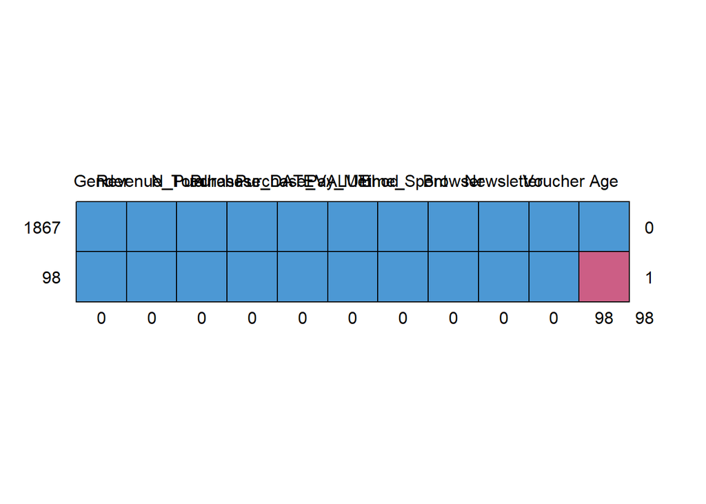

```
##      Gender Revenue_Total N_Purchases Purchase_DATE Purchase_VALUE Pay_Method
## 1867      1             1           1             1              1          1
## 98        1             1           1             1              1          1
##           0             0           0             0              0          0
##      Time_Spent Browser Newsletter Voucher Age
## 1867          1       1          1       1   1  0
## 98            1       1          1       1   0  1
##               0       0          0       0  98 98
```

```r
md.pattern(data_miss)
```

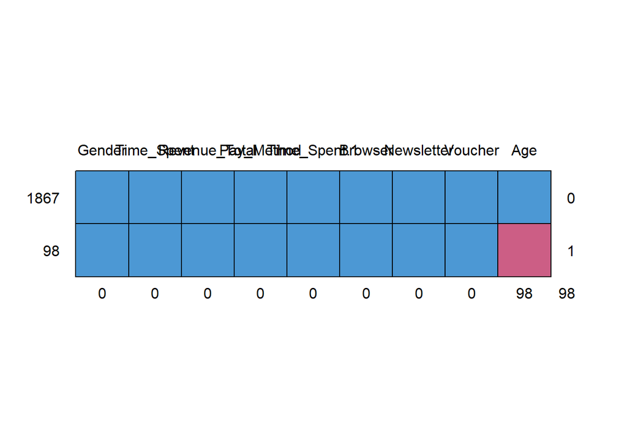

```
##      Gender Time_Spent Revenue_Total Pay_Method Time_Spent.1 Browser Newsletter
## 1867      1          1             1          1            1       1          1
## 98        1          1             1          1            1       1          1
##           0          0             0          0            0       0          0
##      Voucher Age
## 1867       1   1  0
## 98         1   0  1
##            0  98 98
```

```r
md.pattern(data_miss[,c("Gender","Age","Time_Spent","Revenue_Total",  "Pay_Method", "Time_Spent", "Browser", "Newsletter","Voucher")])
```

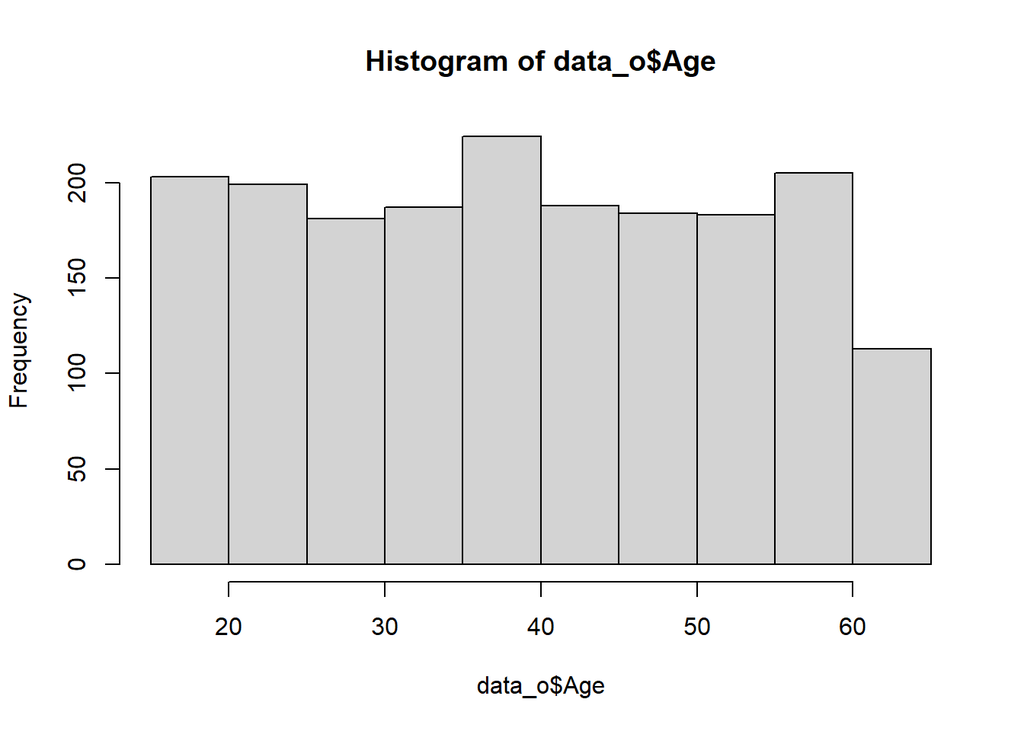

```r
#ortalamayla eksik gözlemlere atama yapalım.
data_o <- data_miss
hist(data_o$Age)
```

```r
data_o$Age[is.na(data_o$Age)] <- mean(data_o$Age,na.rm=TRUE)
```

```r
#Eksik gözlemlere göz atalım.
z <- which(is.na(data_miss$Age))
z
```

```
##  [1]   13   26   34   41   69   72   90  141  153  166  179  195  211  217  277
## [16]  294  309  316  348  373  374  409  415  431  456  463  490  516  519  526
## [31]  528  544  555  581  588  593  598  602  665  709  722  747  752  755  774
## [46]  840  844  859  905  923  928  932  937  938  953  956 1011 1017 1038 1047
## [61] 1063 1113 1115 1140 1142 1159 1167 1183 1233 1247 1248 1253 1268 1302 1314
## [76] 1323 1332 1379 1398 1450 1487 1599 1614 1627 1630 1645 1673 1790 1792 1799
## [91] 1842 1845 1866 1878 1889 1895 1942 1959
```

```r
#Ortalamayla doldurduğumuz eksik gözlemleri inceleyelim.
data_o$Age[z]
```

```
##  [1] 39.3594 39.3594 39.3594 39.3594 39.3594 39.3594 39.3594 39.3594 39.3594
## [10] 39.3594 39.3594 39.3594 39.3594 39.3594 39.3594 39.3594 39.3594 39.3594
## [19] 39.3594 39.3594 39.3594 39.3594 39.3594 39.3594 39.3594 39.3594 39.3594
## [28] 39.3594 39.3594 39.3594 39.3594 39.3594 39.3594 39.3594 39.3594 39.3594
## [37] 39.3594 39.3594 39.3594 39.3594 39.3594 39.3594 39.3594 39.3594 39.3594
## [46] 39.3594 39.3594 39.3594 39.3594 39.3594 39.3594 39.3594 39.3594 39.3594
## [55] 39.3594 39.3594 39.3594 39.3594 39.3594 39.3594 39.3594 39.3594 39.3594
## [64] 39.3594 39.3594 39.3594 39.3594 39.3594 39.3594 39.3594 39.3594 39.3594
## [73] 39.3594 39.3594 39.3594 39.3594 39.3594 39.3594 39.3594 39.3594 39.3594
## [82] 39.3594 39.3594 39.3594 39.3594 39.3594 39.3594 39.3594 39.3594 39.3594
## [91] 39.3594 39.3594 39.3594 39.3594 39.3594 39.3594 39.3594 39.3594
```

```r
library("openxlsx")
write.xlsx(data_o,'satisyeni.xlsx')
```

```r
# İlk önce rasgeleliği sabitleyelim.
set.seed(123456)
```

```r
#Eğitim-test kümesini ayıralım.
trainIndex <- sample(1:nrow(data_o), size = round(0.8*nrow(data_o)), replace = FALSE)
egitimveri <- data_o[trainIndex,]
test <- data_o[-trainIndex,]
```

```r
egitimveri$vouch <- ifelse(egitimveri$Voucher==1,"Kullanıldı","Kullanılmadı")
```

```r
#Kategorik değişkenler
egitimveri<- as.data.frame(egitimveri)
egitimveri$Gender <- as.factor(egitimveri$Gender)
egitimveri$Pay_Method <- as.factor(egitimveri$Pay_Method)
egitimveri$Browser <- as.factor(egitimveri$Browser)
egitimveri$Newsletter <- as.factor(egitimveri$Newsletter)
egitimveri$Voucher <- as.factor(egitimveri$Voucher)
egitimveri$vouch <- as.factor(egitimveri$vouch)
summary(egitimveri)
```

```
##       Age        Gender   Revenue_Total    N_Purchases
##  Min.   :16.00   0: 527   Min.   : 0.50   Min.   :1.000
##  1st Qu.:28.00   1:1045   1st Qu.:15.65   1st Qu.:2.000
##  Median :39.36            Median :30.15   Median :4.000
##  Mean   :39.39            Mean   :27.78   Mean   :4.004
##  3rd Qu.:51.00            3rd Qu.:37.62   3rd Qu.:6.000
##  Max.   :63.00            Max.   :59.90   Max.   :7.000
##  Purchase_DATE                 Purchase_VALUE     Pay_Method   Time_Spent
##  Min.   :2021-01-01 00:00:00   Length:1572        0:442      Min.   : 120.0
##  1st Qu.:2021-04-03 00:00:00   Class :character   1:456      1st Qu.: 341.8
##  Median :2021-06-30 00:00:00   Mode  :character   2:364      Median : 580.5
##  Mean   :2021-07-01 20:30:13                      3:310      Mean   : 587.8
##  3rd Qu.:2021-10-01 00:00:00                                 3rd Qu.: 823.0
##  Max.   :2022-01-01 00:00:00                                 Max.   :1080.0
##  Browser  Newsletter Voucher           vouch
##  0:1015   0:1336     0:1145   Kullanıldı  : 427
##  1: 322   1: 236     1: 427   Kullanılmadı:1145
##  2:  77
##  3: 158
##
##
```

####6.ADIM

###VERİLERİN AÇIKLYAYICI ÇÖZÜMLEMESİ

Kategorik Değişkenler için Frekans

```r
library("funModeling")
freq(egitimveri)
```

```
##   Gender frequency percentage cumulative_perc
## 1      1      1045      66.48           66.48
## 2      0       527      33.52          100.00
```

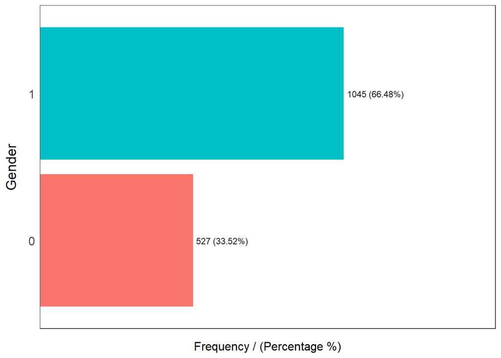

[output not shown]

[output cut: 1395 more lines]

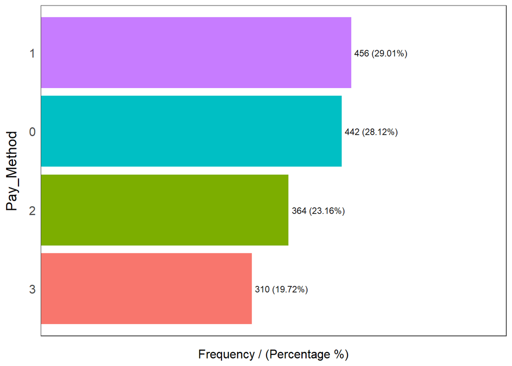

```
##   Pay_Method frequency percentage cumulative_perc
## 1          1       456      29.01           29.01
## 2          0       442      28.12           57.13
## 3          2       364      23.16           80.29
## 4          3       310      19.72          100.00
```

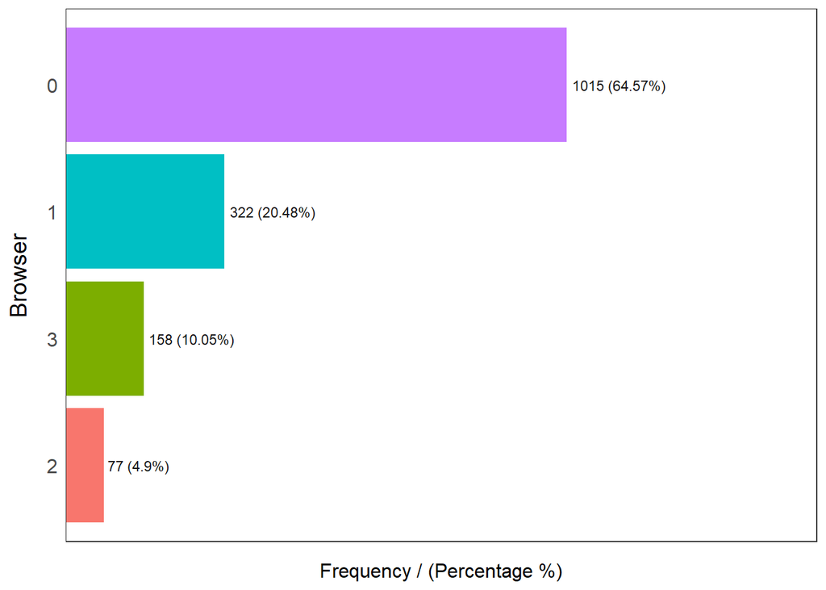

```
##   Browser frequency percentage cumulative_perc
## 1       0      1015      64.57           64.57
## 2       1       322      20.48           85.05
## 3       3       158      10.05           95.10
## 4       2        77       4.90          100.00
```

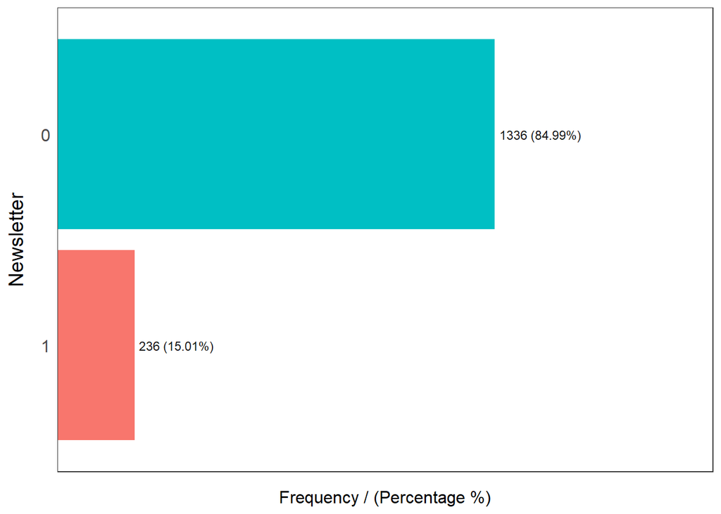

```
##   Newsletter frequency percentage cumulative_perc
## 1          0      1336      84.99           84.99
## 2          1       236      15.01          100.00
```

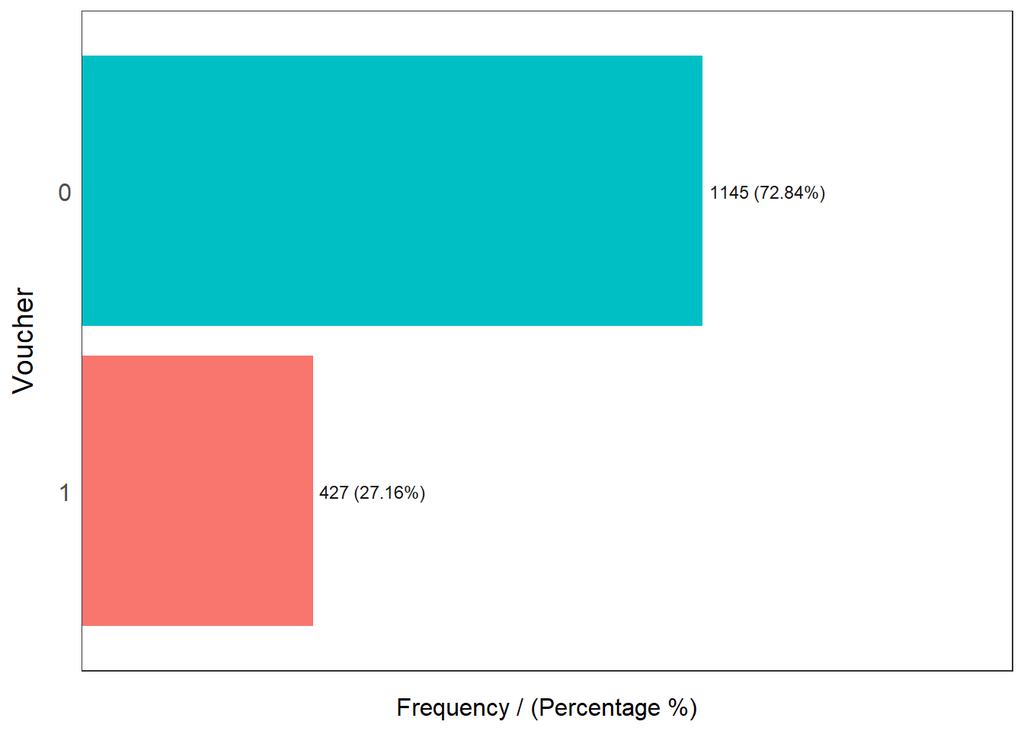

```
##   Voucher frequency percentage cumulative_perc
## 1       0      1145      72.84           72.84
## 2       1       427      27.16          100.00
```

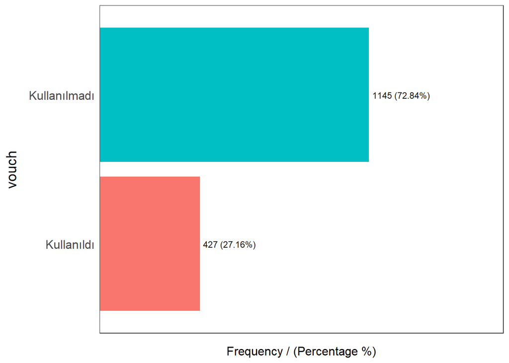

```
##          vouch frequency percentage cumulative_perc
## 1 Kullanılmadı      1145      72.84           72.84
## 2   Kullanıldı       427      27.16          100.00
```

```
## [1] "Variables processed: Gender, Purchase_VALUE, Pay_Method, Browser, Newsletter, Voucher, vouch"
```

Kupon kullananlar 427 kişi iken, Kullanmayanlar 1145 kişidir.

Ödeme Türünde Dijital Cüzdan kullanan 442 kişi, Kart kullanan 456 kişi, Paypal kullanan 364 kişi ve diğer ödeme yöntemi kullanan ise 310 kişidir.

Tarayıcı chrome kullanan 1015 kişi, safari kullanan 322 kişi, Edge kullanan 77 kişi ve diğer tarayıcılar kullanan ise 158 kişidir.

Aboneliği olan 236 kişi iken abone olmayan 1336 kişidir.

###Niceller için Frekans

```r
profiling_num(egitimveri)
```

```
##        variable       mean    std_dev variation_coef p_01   p_05   p_25
## 1           Age  39.390149  13.648505      0.3464954   16  18.00  28.00
## 2 Revenue_Total  27.784606  14.805870      0.5328803    1   3.40  15.65
## 3   N_Purchases   4.003817   2.022152      0.5050562    1   1.00   2.00
## 4    Time_Spent 587.828880 278.359719      0.4735387  128 162.55 341.75
##       p_50    p_75    p_95    p_99     skewness kurtosis     iqr       range_98
## 1  39.3594  51.000   61.00   63.00 -0.015338437 1.886942  23.000       [16, 63]
## 2  30.1500  37.625   53.90   58.70  0.003757110 2.276228  21.975      [1, 58.7]
## 3   4.0000   6.000    7.00    7.00  0.004500411 1.762734   4.000         [1, 7]
## 4 580.5000 823.000 1031.45 1070.29  0.041676688 1.792505 481.250 [128, 1070.29]
##       range_80
## 1     [20, 58]
## 2 [6.31, 47.3]
## 3       [1, 7]
## 4 [207, 970.9]
```

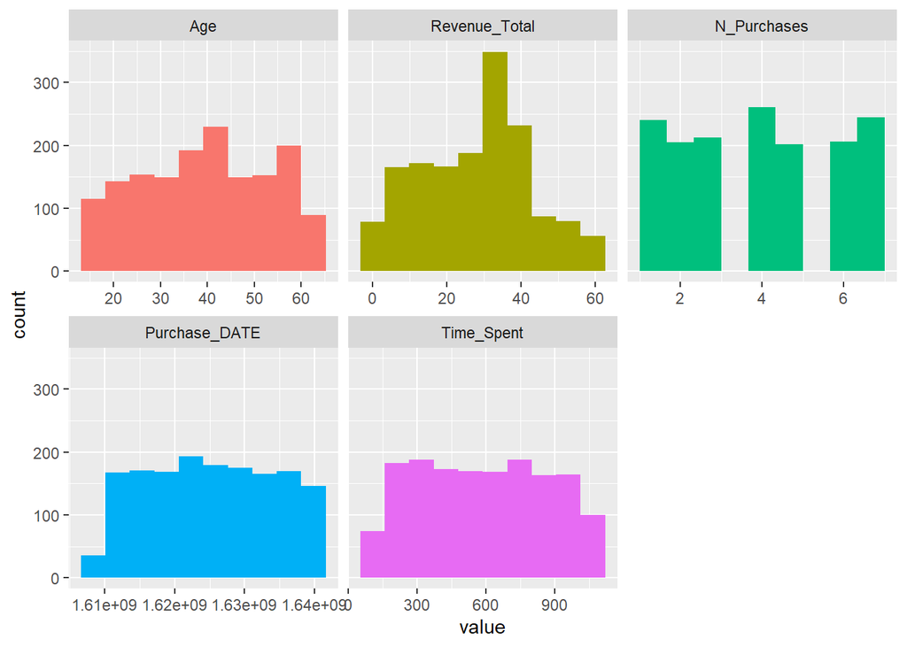

```r
plot_num(egitimveri)
```

Müşteriye göre toplam satışlar ise sola çarpıktır.

###Nokta Özeti

```r
quantile(egitimveri$Revenue_Total)
```

```
##     0%    25%    50%    75%   100%
##  0.500 15.650 30.150 37.625 59.900
```

```r
quantile(egitimveri$Revenue_Total, c(.1,.9))
```

```
##   10%   90%
##  6.31 47.30
```

Müşteriye göre toplam satış tutarı 0,10 ile 0,90 değerleri arasında değerler 6,31 ile 47,30 arasındadır

###DAG

```r
q1 <- as.vector(quantile(egitimveri$Revenue_Total,0.25))
q3 <- as.vector(quantile(egitimveri$Revenue_Total,0.75))
DAG <- q3-q1
DAG
```

```
## [1] 21.975
```

###Genişlik

```r
genislik <- max(egitimveri$Revenue_Total)-min(egitimveri$Revenue_Total)
genislik
```

```
## [1] 59.4
```

###Değişim Ölçüleri

```r
stRev <-stdev <- sd(egitimveri$Revenue_Total)
stRev
```

```
## [1] 14.80587
```

```r
meanRev <- mean <- mean(egitimveri$Revenue_Total)
meanRev
```

```
## [1] 27.78461
```

```r
Degisim_kats_age <- (stdev/mean)*100
Degisim_kats_age
```

```
## [1] 53.28803
```

```r
#Cinsiyete göre yayılımı icin:
sd_dk <- function(x) {c(std<-sd(x), dk<-(sd(x)/mean(x))*100)}
tapply(egitimveri$Revenue_Total, egitimveri$Gender, sd_dk)
```

```
## $`0`
## [1] 14.91713 54.38332
##
## $`1`
## [1] 14.75337 52.75913
```

###MAD

```r
sort <- egitimveri[order(egitimveri$Revenue_Total),]
medianf <- median(sort$Revenue_Total)
sort$fmed <- abs(sort$Revenue_Total-medianf)
sort2 <- sort[order(sort$fmed),]
mad <- median(sort2$fmed)
mad
```

```
## [1] 9.65
```

###Genişletilmiş Nokta Özeti

```r
#Sol kuyruk
sol <- function(x) {
  c(quantile(x, probs = 1/2) ,
    quantile(x, probs = 1/4),
    quantile(x, probs =1/8 ),
    quantile(x,probs=1/16),
    quantile(x,probs=1/32),
    quantile(x,probs=1/64)
  )
}
#Sag kuyruk
sag <- function(x) {
  c(quantile(x, probs = 1/2) ,
    quantile(x, probs = 3/4),
    quantile(x, probs = 7/8),
    quantile(x,probs=15/16),
    quantile(x,probs=31/32),
    quantile(x,probs=63/64)
  )
}
#cinsiyete gore sol kuyruk
y <- tapply(egitimveri$Revenue_Total, egitimveri$Gender, sol)
mrg_cins <- as.data.frame(cbind(y[[1]],y[[2]]))
colnames(mrg_cins) <- c("Female","Male")
mrg_cins$Fark <- abs(mrg_cins$Female-mrg_cins$Male)
mrg_cins
```

[output not shown]

```r
#Kuyruk Uzunlugu Incelemesi
x_a <- sol(egitimveri$Revenue_Total)
x_u <- sag(egitimveri$Revenue_Total)
x_mrg <- as.data.frame(cbind(x_a,x_u))
rownames(x_mrg) <- c("1/2","1/4","1/8","1/16","1/32","1/64")
colnames(x_mrg) <- c("Alt_Kuyruk","Ust_Kuyruk")
x_mrg$orta_nokta <- (x_mrg$Alt_Kuyruk+x_mrg$Ust_Kuyruk)/2
x_mrg
```

```
##      Alt_Kuyruk Ust_Kuyruk orta_nokta
## 1/2    30.15000     30.150   30.15000
## 1/4    15.65000     37.625   26.63750
## 1/8     8.00000     44.700   26.35000
## 1/16    3.91875     51.900   27.90938
## 1/32    2.20000     56.500   29.35000
## 1/64    1.30000     58.100   29.70000
```

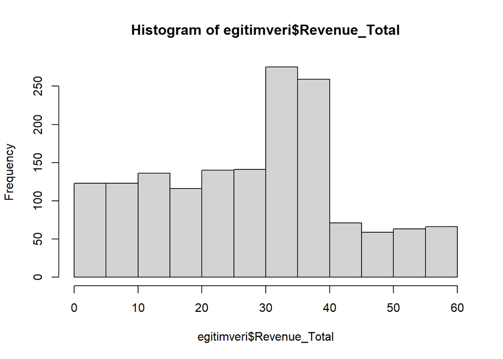

```r
hist(egitimveri$Revenue_Total)
```

###Çarpıklık

```r
library(moments)
skewness(egitimveri$Revenue_Total,na.rm = T)
```

```
## [1] 0.00375711
```

###Basıklık

```r
library(moments)
kurtosis(egitimveri$Revenue_Total,na.rm = T)
```

```
## [1] 2.276228
```

```r
#Kesilmis ortalama
p <- 0.1
mean(egitimveri$Revenue_Total, trim = p)
```

```
## [1] 27.58792
```

```r
#Kalan gozlem sayısı hesaplanmak istenirse:
n <- nrow(egitimveri)
ks <-n-(as.integer(2*p*n))
ks
```

```
## [1] 1258
```

kestirilmiş ortalama 27,58 bulunmuştur

```r
#Geometrik ortalama
library("psych")
geometric.mean(egitimveri$Revenue_Total)
```

```
## [1] 21.65716
```

Geometrik ortalama 21,65 bulunmuştur

```r
#Gini
freq <- as.data.frame(table(egitimveri$Gender))
names(freq)[1] <- 'cinsiyet'

gini <- function(a,b) {
  a1 <- (a/(a+b))**2
  b1 <- (b/(a+b))**2
  x<-1-(a1 + b1)
  return(x)
}
gn <- gini(freq[1,2],freq[2,2])
k <- 2
gn/((k-1)/k)
```

```
## [1] 0.8914189
```

```r
#Entropi
entropy <- function(base,a,b) {
  var <-  abs(((a)/(a+b))*log(((a)/(a+b)),base))-(((b)/(a+b))*log(((b)/(a+b)),base))
  return(var)
}
ent <- entropy(10,freq[1,2],freq[2,2])
k <- 2
ent/(log(k,10))
```

```
## [1] 0.9201924
```

Gini değeri 0,89 olduğundan 1 değerine daha yakındır bu yüzden düzensizlik olduğu söylenebilir. Homojen değildir

Entropi deperi 0,92 olduğundan 1 değerine daha yakındır bu yüzden düzensizlik olduğu söylenebilir. Homojen değildir.

```r
#Chi-square
dt_c <- table(egitimveri$Revenue_Total,egitimveri$Age)
dtc_exp <- chisq.test(dt_c)$expected
rowcs <- function(i, obs, exp) {
  sum(((obs[i,] - exp[i,])^2)/exp[i,])
}

chi_dtc <- as.matrix(lapply(seq_len(nrow(dt_c)), rowcs, obs = dt_c, exp = dtc_exp))
rownames(chi_dtc) <- rownames(dt_c)
chi_dtc
```

[output not shown]

[output cut: 415 more lines]

```
## 56.7 42.43284
## 57.1 51.18065
## 57.3 42.36089
## 57.5 45.69459
## 57.7 41.48649
## 57.9 48.44948
## 58.1 55.44234
## 58.3 56.83968
## 58.7 49.86964
## 58.9 48.01818
## 59.1 57.22222
## 59.3 79.29131
## 59.5 46.65714
## 59.7 58.46154
## 59.9 46.40699
```

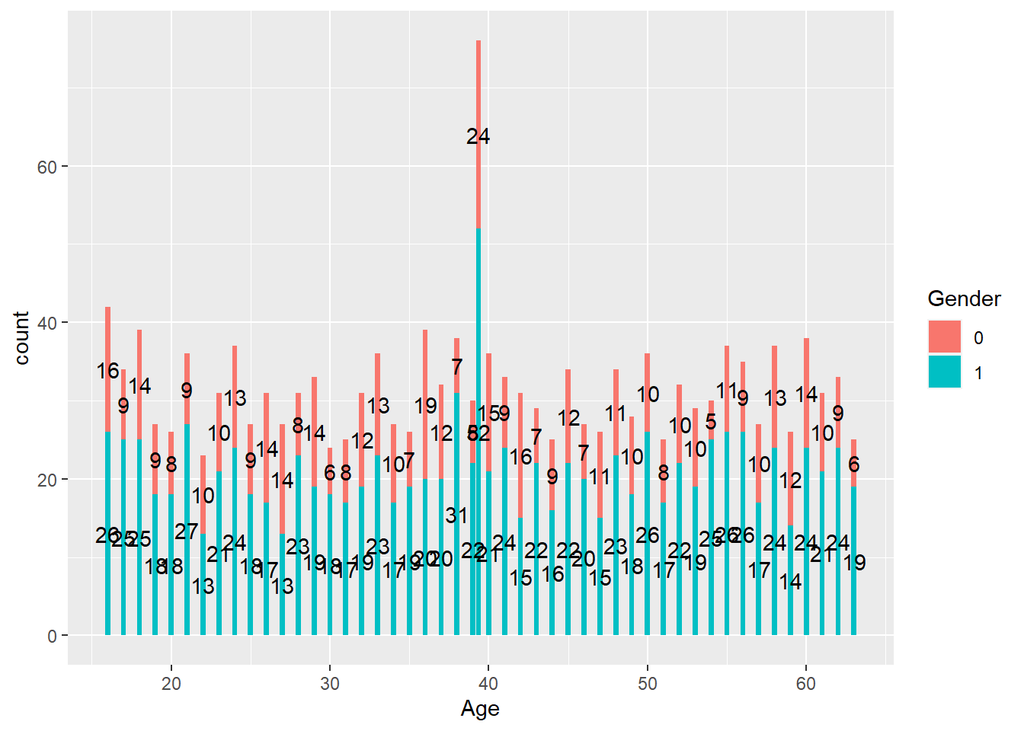

```r
#BAR PLOT
library(ggplot2)
ggplot(egitimveri, aes(Age, fill = Gender)) +
  geom_bar() +
  geom_text(aes(label=..count..),stat="count",position=position_stack(0.5))
```

Cinsiyet ve yaşa göre kıyaslama yapıldığında kadın müşterilerin erkek müşterilere göre daha fazla olduğu söylenebilir.

```r
#Yuzdesel olarak:
library(dplyr)
tra_pct <- egitimveri %>% group_by(Age, Gender) %>%
  dplyr::summarise(count=n()) %>%
  mutate(pct=round(count/sum(count),2))
```

[output not shown]

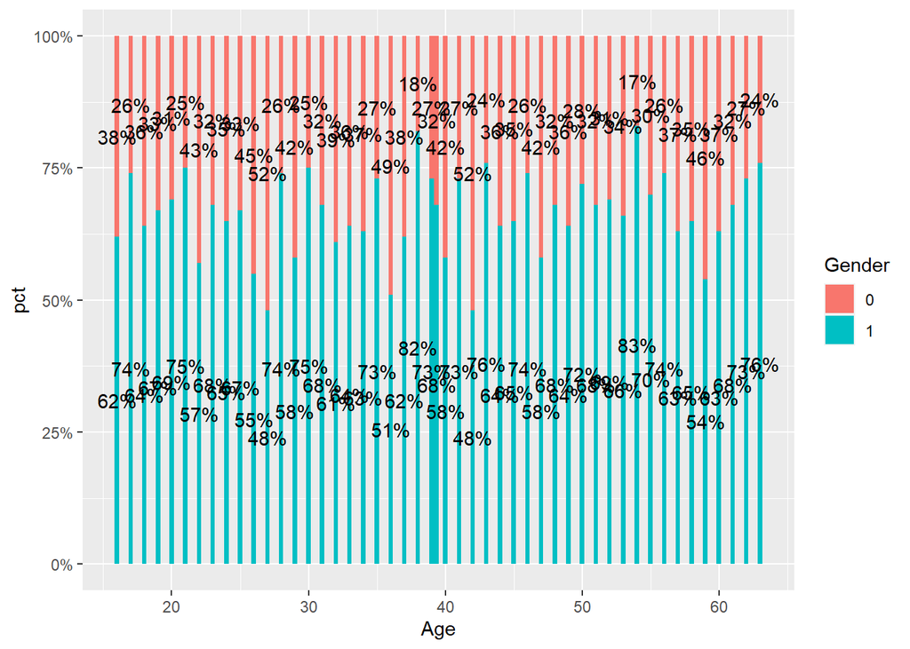

```r
ggplot(tra_pct, aes(Age, pct, fill = Gender)) +
  geom_bar(stat='identity') +
  geom_text(aes(label=scales::percent(pct)), position = position_stack(vjust = .5))+
  scale_y_continuous(labels = scales::percent)
```

Cinsiyet ve yaşa göre yüzdesel kıyaslama yapıldığında kadın müşterilerin erkek müşterilere göre daha fazla olduğu söylenebilir.

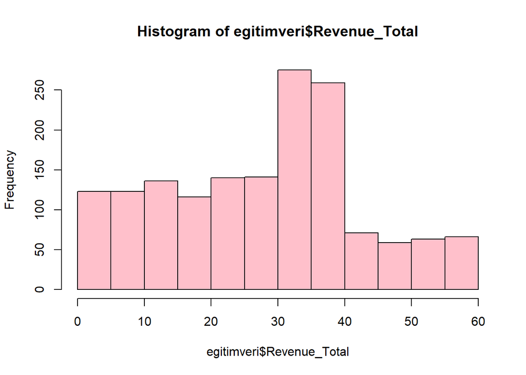

```r
#HISTOGRAM
hist(egitimveri$Revenue_Total, col = "pink")
```

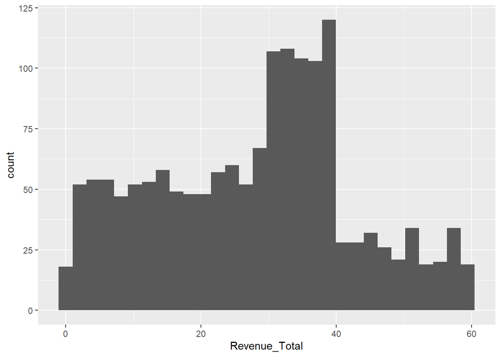

```r
#Ya da
ggplot(egitimveri,aes(Revenue_Total))+
  geom_histogram()
```

Müşteriye göre toplam satış tutarı sola çarpık olduğu söylenebilir

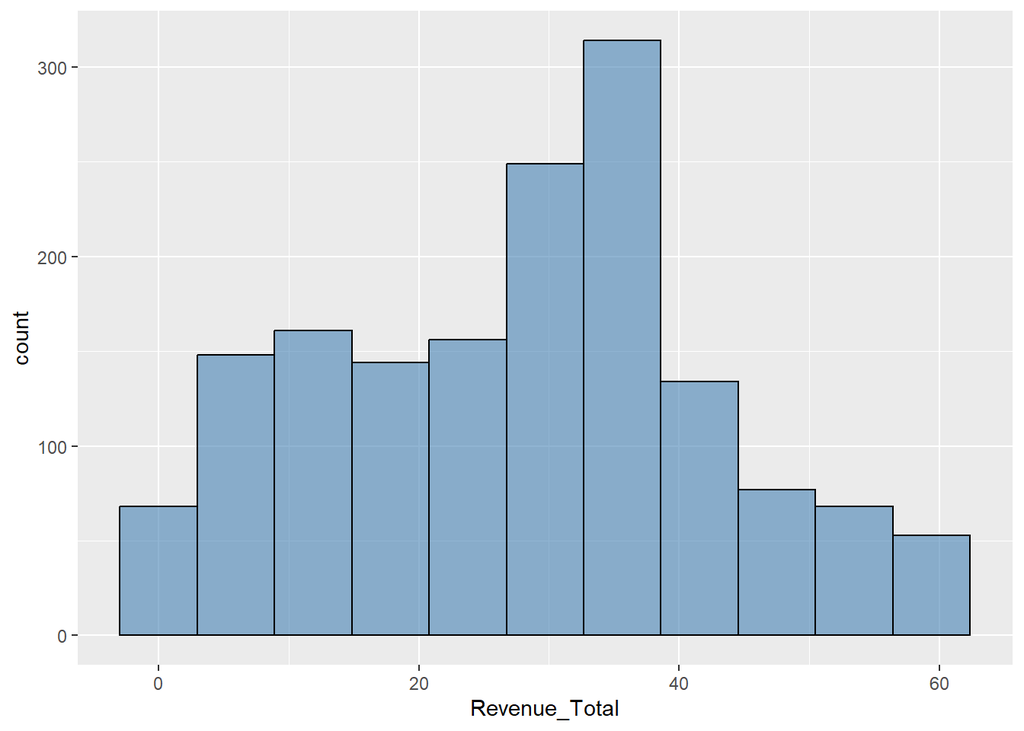

```r
k <- ceiling((log(2*nrow(egitimveri)))+1)
genislik <- max(egitimveri$Revenue_Total)-min(egitimveri$Revenue_Total)
binw <- genislik/k

ggplot(egitimveri,aes(Revenue_Total))+
  geom_histogram(binwidth=binw,
                 fill="steelblue",colour="black", alpha=0.6)
```

Müşteriye göre toplam satışının toplam sayısına bakıldığında normale yakın dağıldığı gözükmektedir.

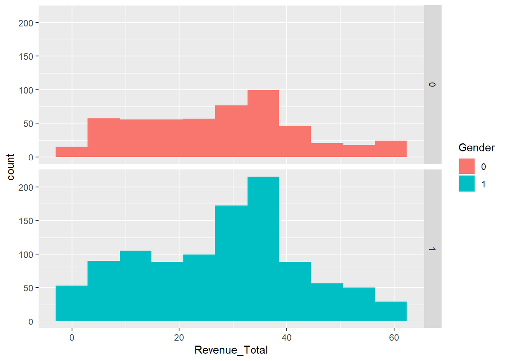

```r
#Kategorik degisken düzeylerinde kırılım:
ggplot(egitimveri,aes(Revenue_Total,fill=Gender))+
  geom_histogram(binwidth=binw)+
  facet_grid(Gender~.)
```

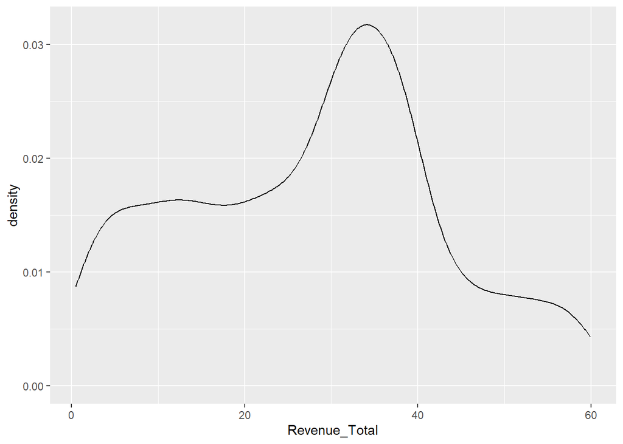

```r
#Yogunluk grafigi
ggplot(egitimveri,aes(Revenue_Total))+
  geom_density()
```

Karma bir dağılım olduğu görülmektedir.

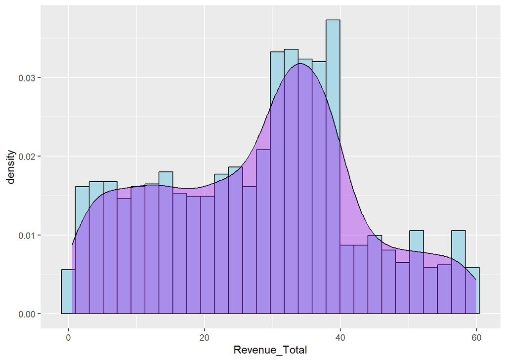

```r
#Histogram+Yogunluk bırlıkte
ggplot(egitimveri,aes(Revenue_Total))+
  geom_histogram(aes(y=..density..), fill="lightblue", color="black")+
  geom_density(alpha=.4,fill="purple")
```

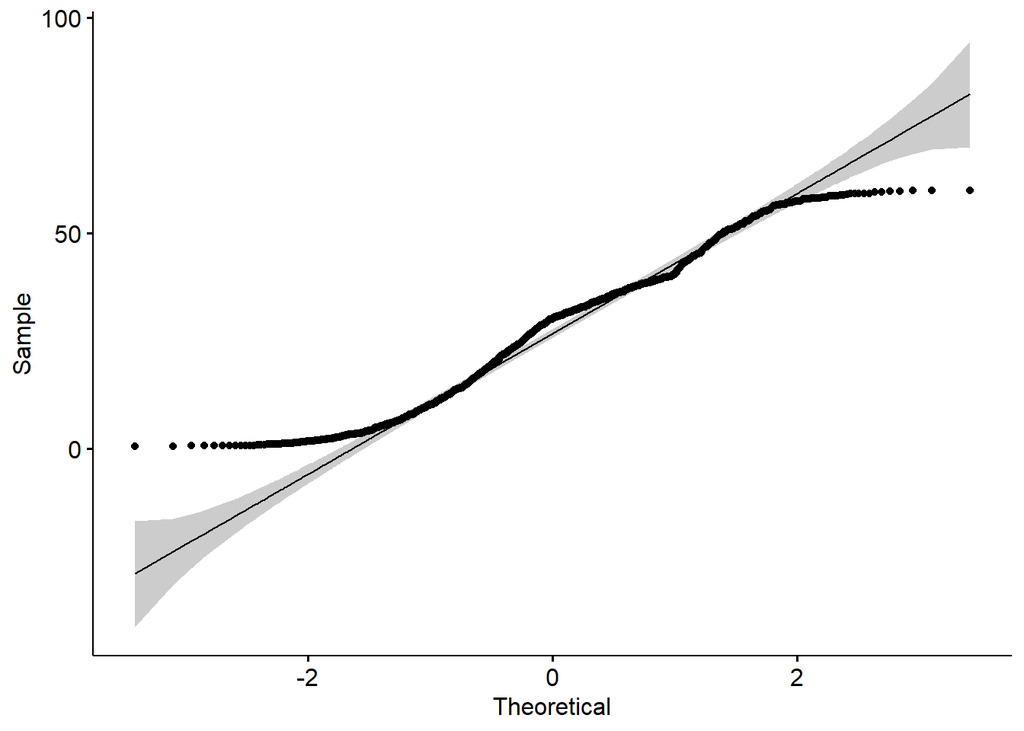

```r
#Q-Q PLOT
library(ggpubr)
ggqqplot(egitimveri$Revenue_Total)
```

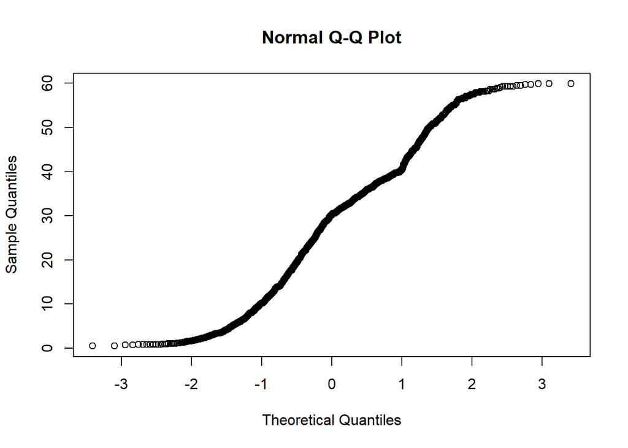

```r
qqnorm(egitimveri$Revenue_Total)
```

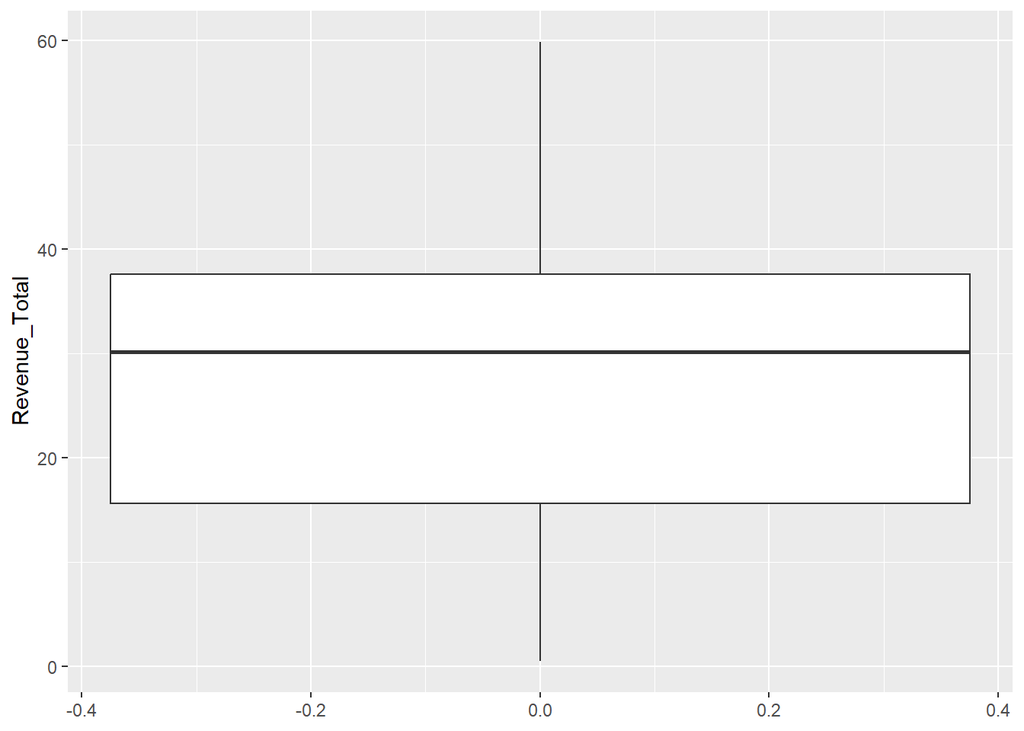

```r
#BOX PLOT
library(ggplot2)
ggplot(egitimveri, aes(y=Revenue_Total))+
  geom_boxplot()
```

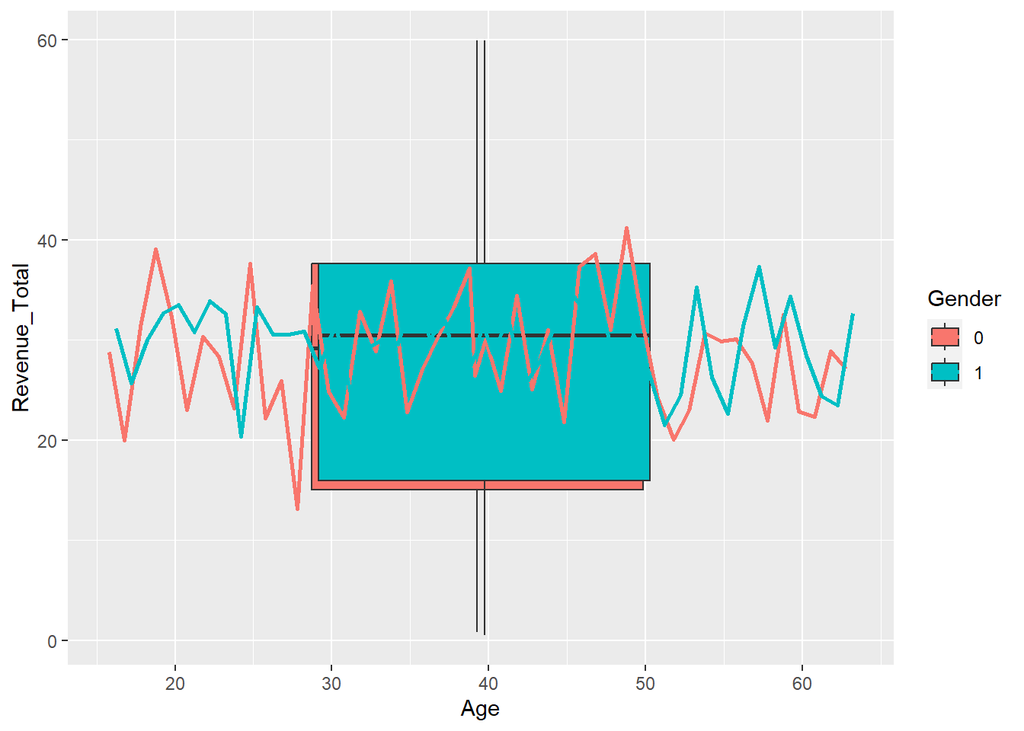

```r
#3. bir kategorik degiskenin de eklenmesi:
ggplot(egitimveri, aes(x = Age, y = Revenue_Total, fill = Gender)) +
  geom_boxplot(position = position_dodge(width = 0.9)) +
  stat_summary(fun = median,geom = 'line',
               aes(group = Gender, colour = Gender),size=1,
               position = position_dodge(width = 0.9))
```

```r
#Sacılım Cizimi:
library(tidyverse)
```

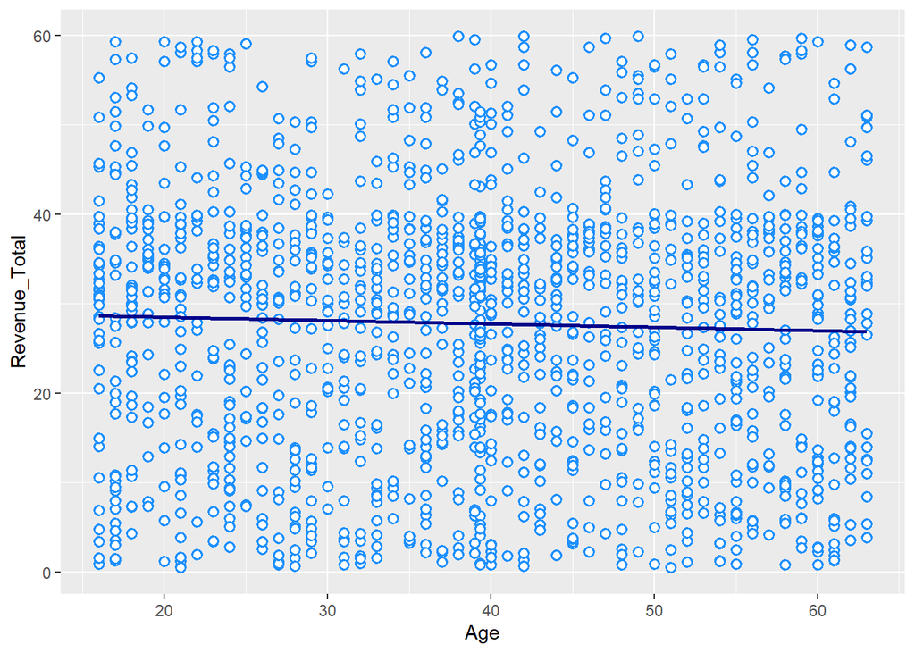

```r
ggplot(egitimveri, aes(Age,Revenue_Total))+
  geom_point(size=2,shape=21,stroke=1,color="dodgerblue1", fill="white")+
  geom_smooth(method = "lm", col="darkblue",se = FALSE)
```

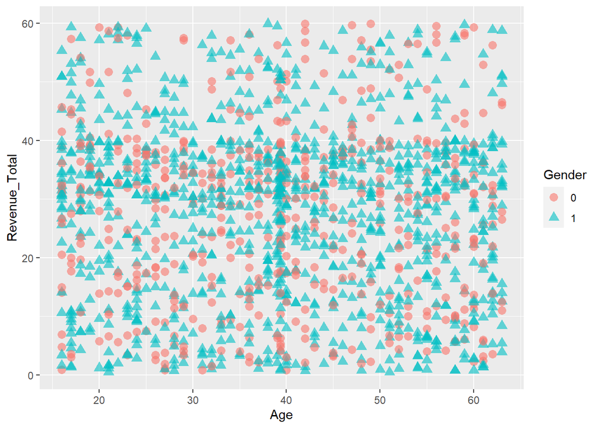

```r
#Ikili-cinsiyet kırılımında:
ggplot(egitimveri, aes(Age,Revenue_Total, color=Gender, shape=Gender))+
  geom_point(size=3,alpha=0.6)
```

Genel olarak baktığımızda her tarafa eşit gibi görülen dağılımda az yoğunlukta ortada toplanmaktadır.

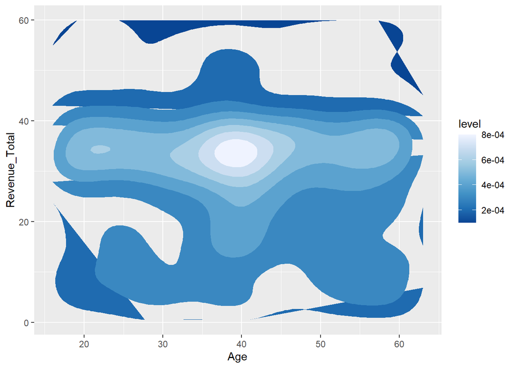

```r
ggplot(egitimveri, aes(x=Age, y=Revenue_Total) ) +
  stat_density_2d(aes(fill = ..level..), geom = "polygon")+
  scale_fill_distiller(palette = "Blues")#direction=1
```

```r
#SACILIM MATRISLERI
cor_veri <- egitimveri[,c(3,1,2)]
library(GGally)
```

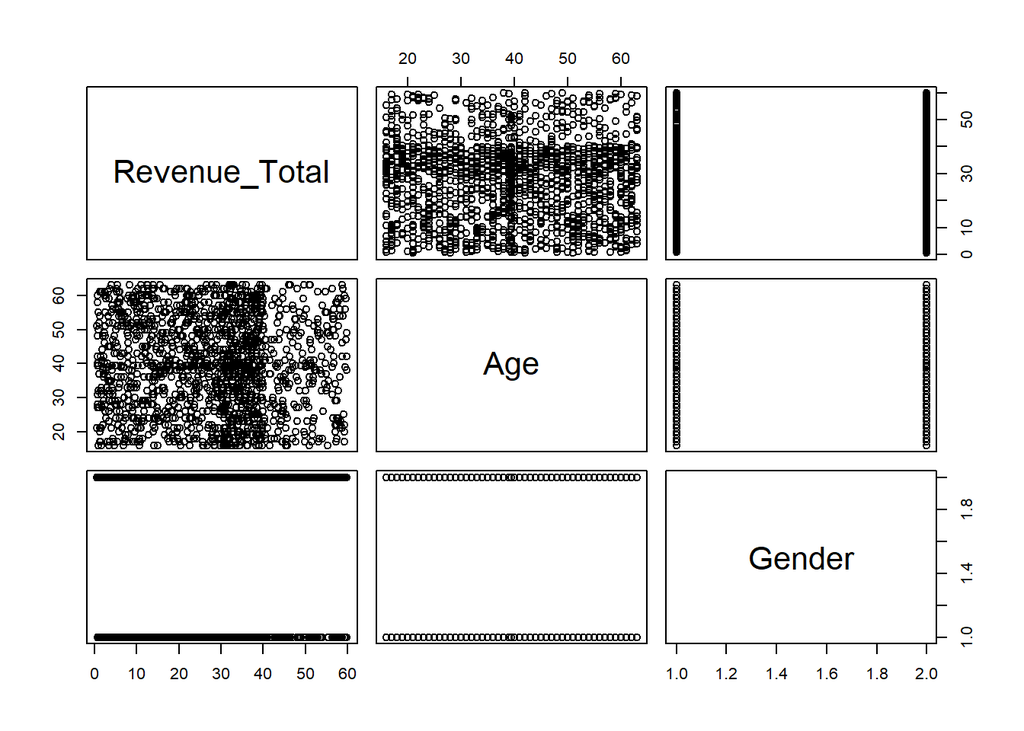

```r
#cor(cor_veri)#Korelasyon degerleri
plot(cor_veri)
```

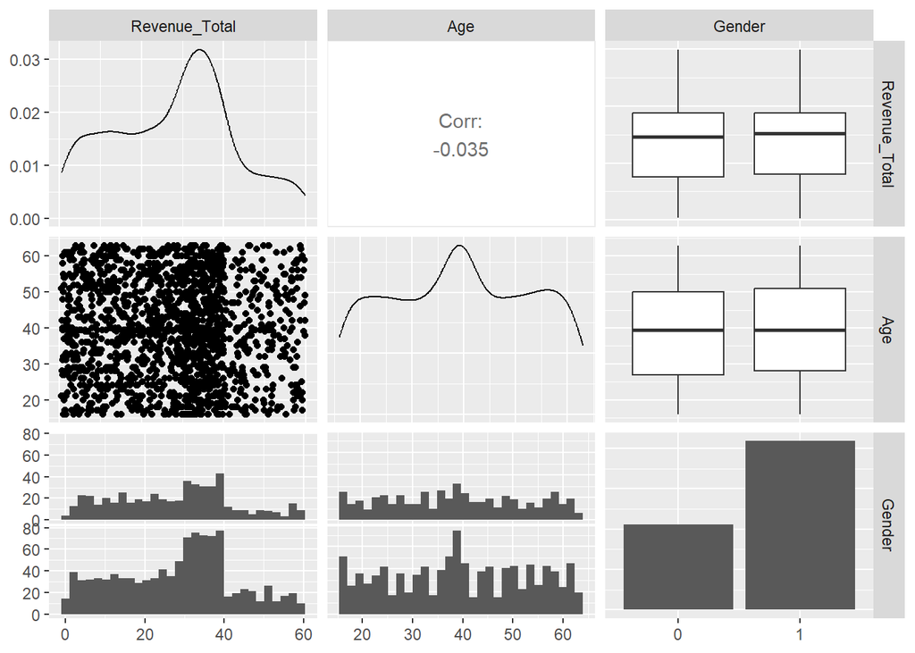

```r
ggpairs(cor_veri)#yogunluk+sacılım+corr
```

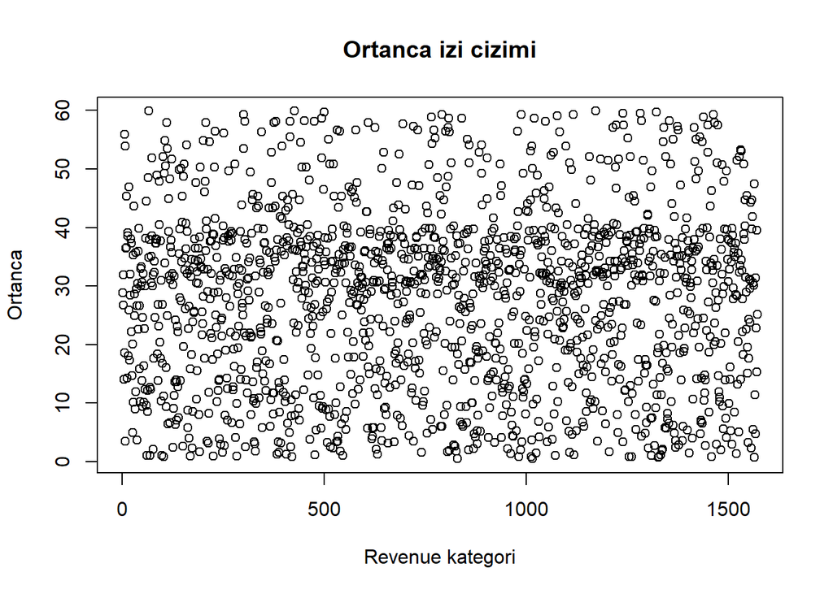

```r
#Ortanca Izi Cizimi
plot(egitimveri$Revenue_Total,egitimveri$Median, xlab="Revenue kategori", ylab="Ortanca", main="Ortanca izi cizimi")
```

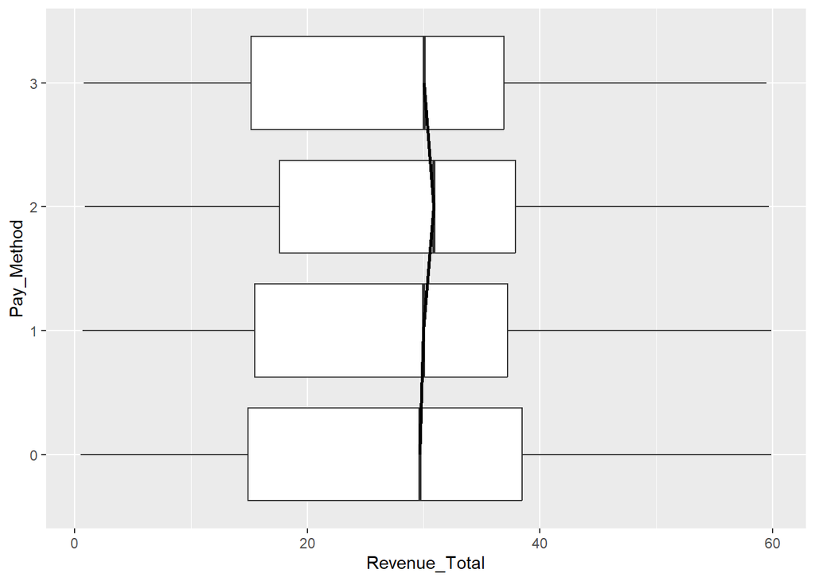

```r
#Buradan da gorulur:
ggplot(egitimveri, aes(x=Revenue_Total,y=Pay_Method, fill=Age))+
  geom_boxplot()+
  stat_summary(fun = median, geom="line", group= 1, color= "black", size = 1)
```

Ortanca değerlerinden eğri çizildiğinde doğrusala yakın olduğu görülmektedir.

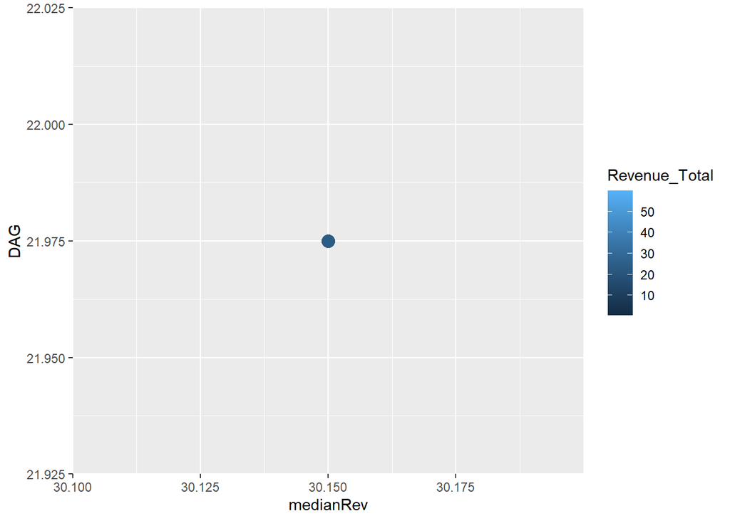

```r
#Konum-Varyans Cizimi
medianRev <- median(egitimveri$Revenue_Total)
ggplot(egitimveri, aes(x=medianRev,y=DAG, color=Revenue_Total, group=1))+
  geom_point(size=4,alpha=0.6)+
  geom_line(color="black")
```

DAG değeri 21,975 ile Medyan değeri 30,150 noktasında toplandığı görülmektedir.

####7.ADIM

###Birliktelik

```r
#02.05

#ETKILESIM
#2 değişenin yani cinsiyet ile yaşın birlikte etkisi var mı yok mu bunu incelemek icin:
etksatis <- egitimveri%>%
  group_by(Gender,Age)%>%
  summarise(Median=median(Revenue_Total))
etksatis
```

```
## # A tibble: 98 x 3
## # Groups:   Gender [2]
##    Gender   Age Median
##    <fct>  <dbl>  <dbl>
##  1 0         16   28.8
##  2 0         17   20
##  3 0         18   31.3
##  4 0         19   39.1
##  5 0         20   32.3
##  6 0         21   23
##  7 0         22   30.4
##  8 0         23   28.4
##  9 0         24   23.2
## 10 0         25   37.6
## # i 88 more rows
```

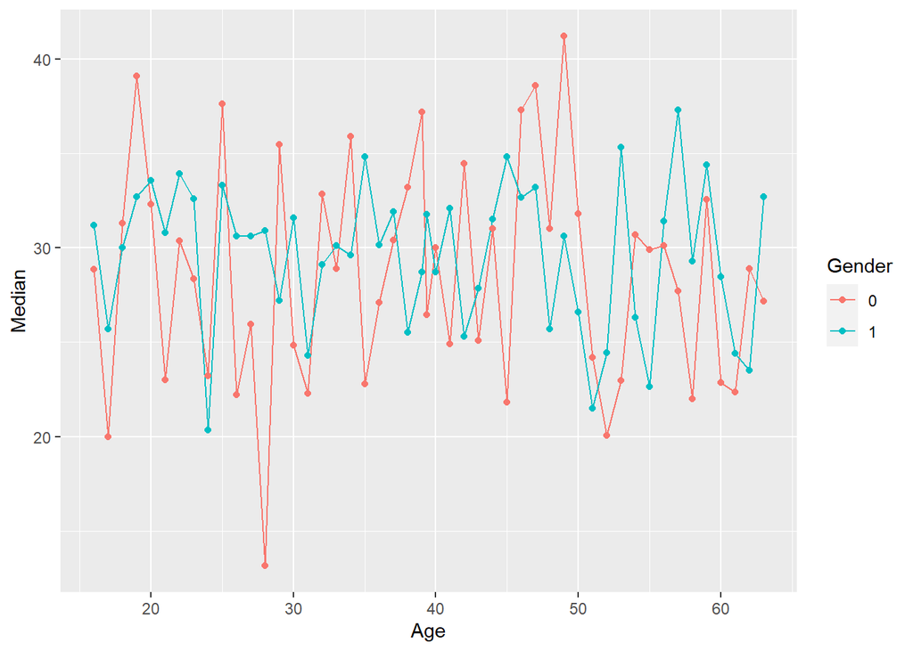

```r
ggplot(etksatis, aes(x = Age, y = Median,color=Gender,group=Gender)) +
  geom_line() +
  geom_point()
```

Cinsiyet ve yaşın, toplam satış sayısına göre etkileşim içerisinde olduğu söylenebilir.

```r
etksatis <- egitimveri%>%
  group_by(Gender,Pay_Method)%>%
  summarise(Median=median(Revenue_Total))
etksatis
```

```
## # A tibble: 8 x 3
## # Groups:   Gender [2]
##   Gender Pay_Method Median
##   <fct>  <fct>       <dbl>
## 1 0      0            29.2
## 2 0      1            29.2
## 3 0      2            30.5
## 4 0      3            28.9
## 5 1      0            29.7
## 6 1      1            30.7
## 7 1      2            31.0
## 8 1      3            30.4
```

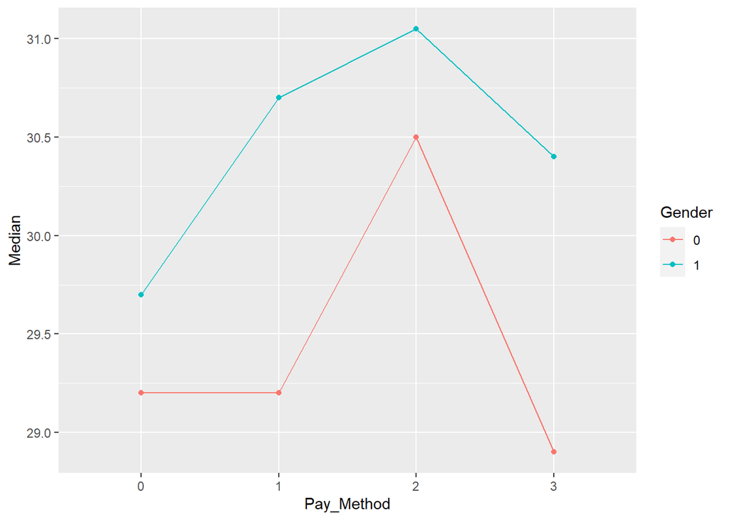

```r
ggplot(etksatis, aes(x = Pay_Method, y = Median,color=Gender,group=Gender)) +
  geom_line() +
  geom_point()
```

Kesişmediği için etkileşim yoktur.

####8.ADIM

###Dönüşüm

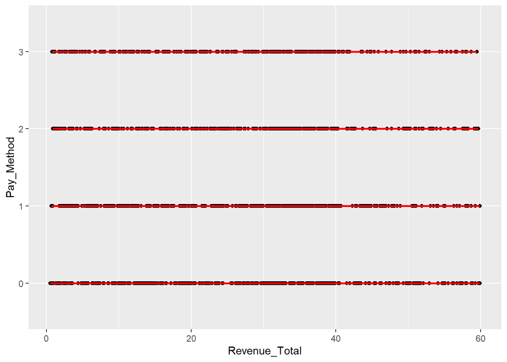

```r
#Boy-Revenue_Total:
ggplot(egitimveri, aes(Revenue_Total,Pay_Method))+
  geom_point()+
  geom_smooth(method = "loess", col="red",se = FALSE)
```

```r
egitimveri$Revenue_Total_log<-log10(egitimveri$Revenue_Total) # logaritmik dönüsüm
```

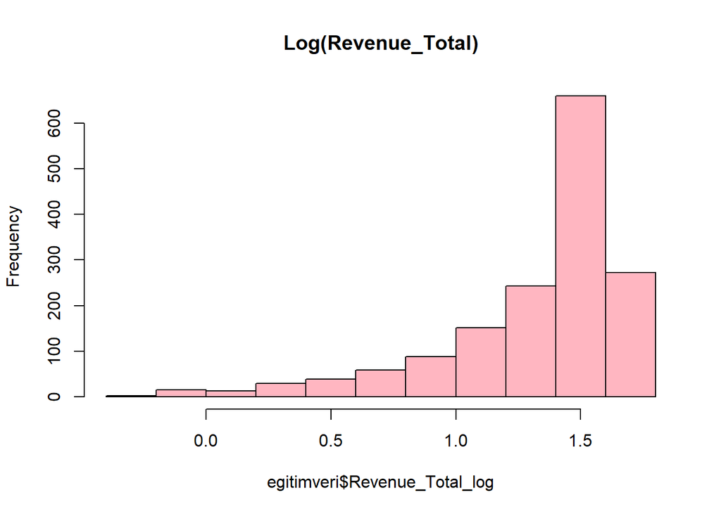

```r
#yeniden grafiklerine bakılırsa;
hist(egitimveri$Revenue_Total_log, col = "lightpink",main="Log(Revenue_Total)")
```

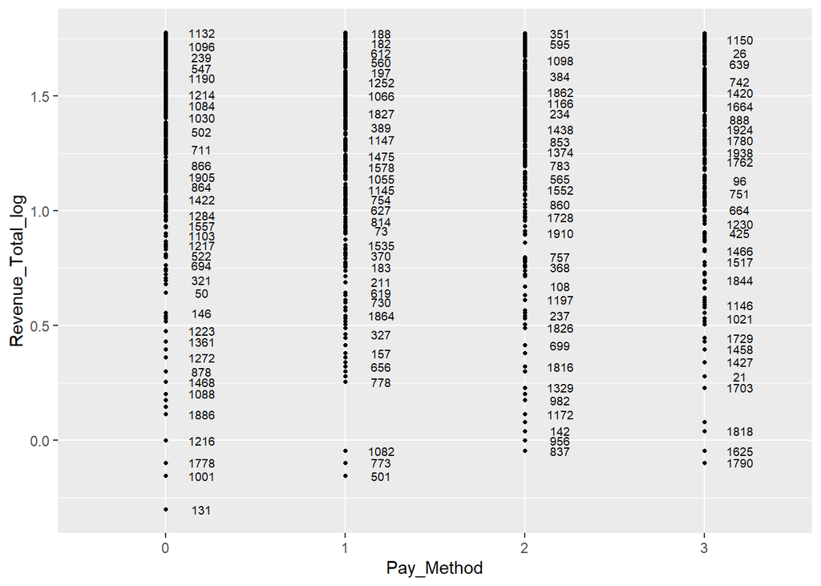

```r
ggplot(egitimveri, aes(Pay_Method,Revenue_Total_log,label=rownames(egitimveri)))+
  geom_point(size=0.90) + geom_text(label=rownames(egitimveri),nudge_x=0.20,check_overlap=T,size=2.5)+
  geom_smooth(method="loess",col="red",se=FALSE)
```

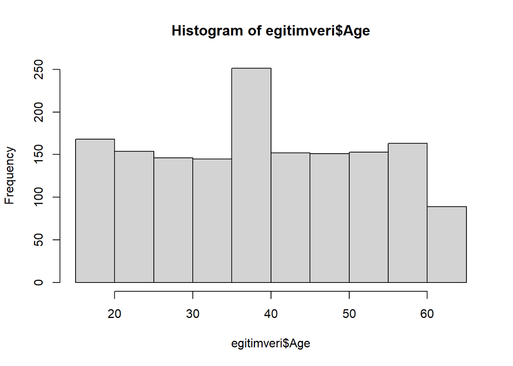

```r
#Age-FEV
hist(egitimveri$Age)
```

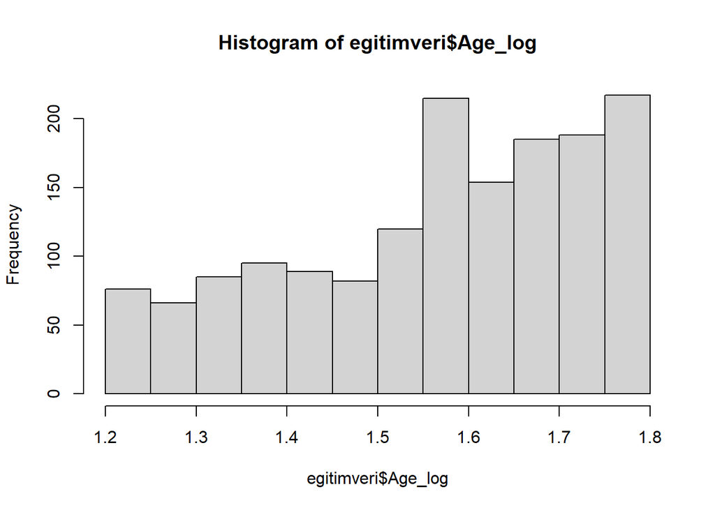

```r
egitimveri$Age_log<-log10(egitimveri$Age) #Age'de logaritmik dönüsüm
hist(egitimveri$Age_log)
```

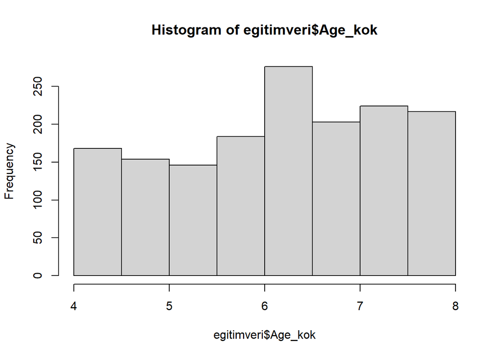

```r
egitimveri$Age_kok<-sqrt(egitimveri$Age) #Age'de kok dönüsümü
hist(egitimveri$Age_kok)
```

1.Normal dağılım olmayıp basık bir grafiktir. 2.Sola çarpık dağılım ve sivri dağılım görülmektedir 3.Sola çarpık dağılım ve basık dağılım görülmektedir

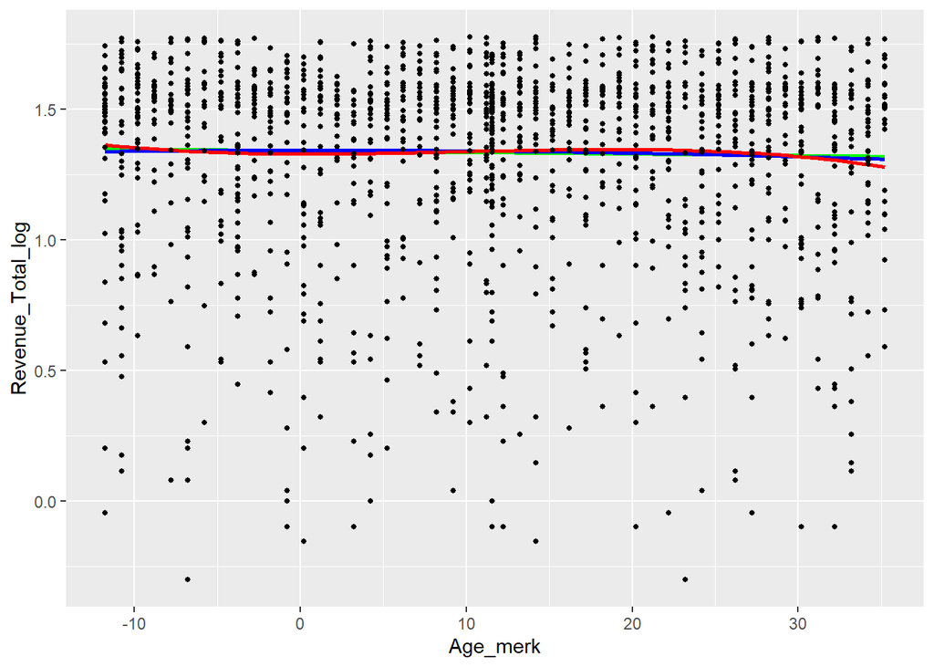

```r
#polinomial
#merkezilestirme:
mean_age <- mean(egitimveri$Revenue_Total)
egitimveri$Age_merk <- (egitimveri$Age-mean_age)

library(ggplot2)
ggplot(egitimveri, aes(x = Age_merk, y =Revenue_Total_log )) +
  stat_smooth(method = "lm", se = FALSE, color = "green", formula = y ~ x) +
  stat_smooth(method = "lm", se = FALSE, color = "blue", formula = y ~ x + I(x ^ 2)) +
  stat_smooth(method = "lm", se = FALSE, color = "red", formula = y ~ x + I(x ^ 2)+ I(x ^ 3)) +
  geom_point(colour = "black", size = 1)
```

```r
#Tukey's Ladder
library(rcompanion)
```

```r
FEV_tukey <- transformTukey(egitimveri$Revenue_Total,plotit=FALSE)
```

```
##
##     lambda      W Shapiro.p.value
## 439   0.95 0.9747       5.105e-16
##
## if (lambda >  0){TRANS = x ^ lambda}
## if (lambda == 0){TRANS = log(x)}
## if (lambda <  0){TRANS = -1 * x ^ lambda}
```

```r
Age_tukey <- transformTukey(egitimveri$Age, plotit=FALSE)
```

```
##
##     lambda     W Shapiro.p.value
## 436  0.875 0.959       1.207e-20
##
## if (lambda >  0){TRANS = x ^ lambda}
## if (lambda == 0){TRANS = log(x)}
## if (lambda <  0){TRANS = -1 * x ^ lambda}
```

```r
#BOX-COX
library(MASS)
```

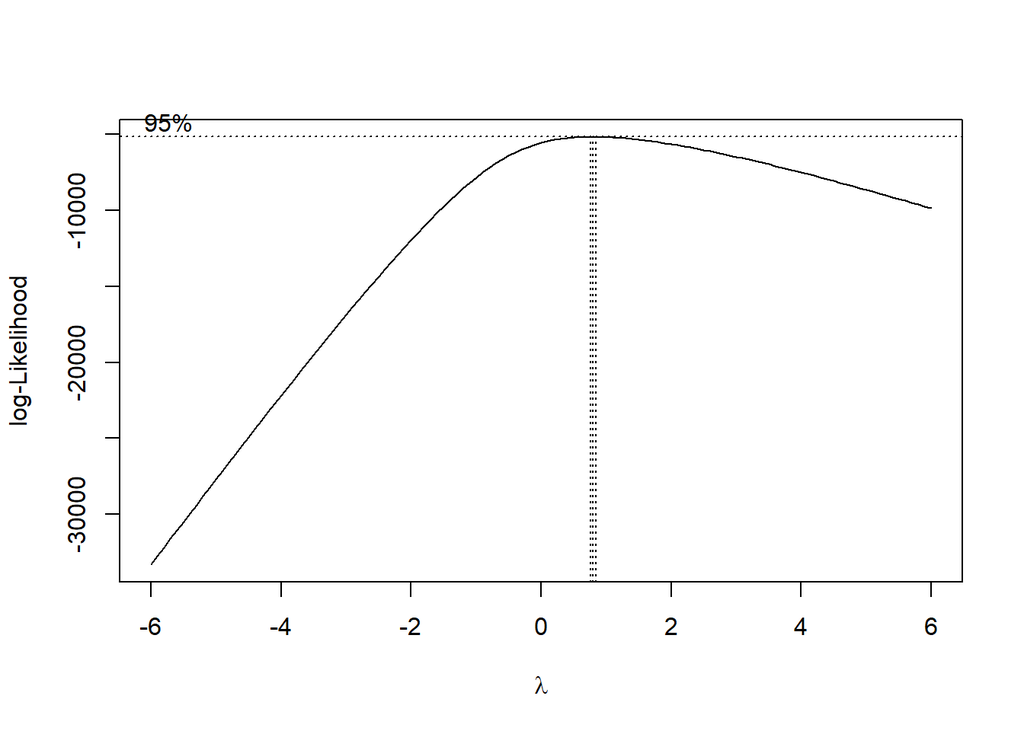

```r
#FEV icin
Box_kol <- boxcox(egitimveri$Revenue_Total ~ 1,
                  lambda = seq(-6,6,0.1))      # Try values -6 to 6 by 0.1
```

```r
Cox_kol <- data.frame(Box_kol$x, Box_kol$y)
Cox_kol <- Cox_kol[order(-Cox_kol$Box_kol.y),]
Cox_kol[1,]
```

```
##    Box_kol.x Box_kol.y
## 69       0.8 -5169.038
```

```r
lambda <- Cox_kol[1, "Box_fev.x"]
lambda
```

[output not shown]

Parabolik dağılım görülmektedir.

###Sonuç olarak,

Verilerin nasıl dağılım gösterdiği, nitel nicel durumu, gerekli olan grafikleri kullanarak analiz yapılmıştır.

Kupon kullanımı, Ödeme türü, Toplam satış sayısı gibi değişkenleri kullanarak analiz yapılmıştır.

###Kaynakça

Veri Linki https://www.kaggle.com/datasets/onlineretailshop/online-shop-customer-sales-data